# ACTG175 Binary Harm Search: Multi-Engine Simulation Study

Author

forestsearch v0.2.0

Published

June 3, 2026

# 1 Overview

The design isolates two questions the León et al. (2024) precursor could not address jointly:

1. **Selection focus.** Within the consistency ensemble, how do `eff` (stability-first), `effMaxSG` (broad, band-aware), and the engine-direct selectors trade off detection, the sensitivity/specificity/PPV/NPV quartet, bias, and realized subgroup size?
2. **Engine choice under a common inference backbone.** Because `dina-*` and `grf-*` are run *through* `forestsearch()`, they inherit the bias-corrected bootstrap + jackknife post-selection inference their native implementations lack. The arms therefore differ only in *who selects the subgroup*, with the inference layer held fixed — a within-engine comparison rather than a cross-method one.

All operating characteristics use the León et al. (2024) Table 1 conventions: the true marginal effect is denoted $\theta^\dagger(\cdot)$ on the natural-parameter scale (here the **odds ratio** for the binary adverse outcome), detection is $\mathrm{any}(\cdot)$, and the classification quartet $\{\text{sens}(\hat H), \text{ppv}(\hat H), \text{sens}(\hat H^c), \text{ppv}(\hat H^c)\}$ is averaged **unconditionally** (a replication with no detected subgroup contributes sens $= 0$, ppv $= 0$ for $\hat H$ and spec $= 1$, npv $= 1$ for $\hat H^c$).

**Libraries, base FS parameters, notation, helpers (click to expand)**

```r
library(forestsearch)
library(speff2trial)
library(data.table)
library(gt)
library(ggplot2)
library(doFuture)
library(foreach)

set.seed(8316951L)

`%||%` <- function(a, b) if (is.null(a)) b else a

# Tidy a cut-string for DISPLAY only (rounds full-precision thresholds to
# `digits` significant figures and collapses ragged whitespace; integer cuts
# untouched).  Does NOT alter the stored sg.def used for evaluation.
tidy_sg_def <- function(s, digits = 4L) {
  if (length(s) != 1L || is.na(s) || !nzchar(s)) return(s)
  s <- gsub("[[:space:]]+", " ", s)
  m <- gregexpr("-?[0-9]+\\.[0-9]+", s)[[1L]]
  if (m[1L] == -1L) return(s)
  L <- attr(m, "match.length")
  for (i in rev(seq_along(m))) {
    num <- as.numeric(substr(s, m[i], m[i] + L[i] - 1L))
    rep <- sub("\\.$", "", formatC(signif(num, digits), format = "fg", flag = "#"))
    s <- paste0(substr(s, 1L, m[i] - 1L), rep, substr(s, m[i] + L[i], nchar(s)))
  }
  s
}

# -- Shared _utils (cross-method comparison plots) ---------------------------
# Locate quarto/_utils by walking up from the render directory, so this file
# works at any nesting depth (e.g. simulations/actg175/binary_methods/).
.find_dir_upwards <- function(target, start = ".", max_up = 7L) {
  d <- normalizePath(start, winslash = "/", mustWork = FALSE)
  for (i in seq_len(max_up)) {
    cand <- file.path(d, target)
    if (dir.exists(cand)) return(cand)
    parent <- dirname(d)
    if (identical(parent, d)) break          # reached filesystem root
    d <- parent
  }
  stop(sprintf("Could not locate '%s' within %d levels above '%s'.",
               target, max_up, normalizePath(start, mustWork = FALSE)),
       call. = FALSE)
}
.util_dir <- .find_dir_upwards("_utils")
source(file.path(.util_dir, "plot_oc_metrics.R"))
source(file.path(.util_dir, "compute_oc_pareto_flag.R"))
source(file.path(.util_dir, "compute_oc_score.R"))

# ===========================================================================
# BASE FORESTSEARCH PARAMETERS  (specified here, not sourced from _fsparams)
# ---------------------------------------------------------------------------
# Rationale: the `methods` interface collapses the former per-sg_focus qmd
# fleet into this single document, so the external bundle's reason to exist
# (keeping sibling qmds in sync) no longer applies.  These are the SHARED
# base; per-arm engine / focus / screening overrides are injected by the
# `methods` expander and take precedence (default_sim_params() -> fs_params
# -> per-arm overrides).  Revise values here.
#
# stop_threshold = NULL is the cross-focus-safe choice: the band-aware focuses
# (effMaxSG) require NULL, and for `eff` it simply disables early stopping.
# ===========================================================================
fs_base <- list(
  # -- Identifiers (match simulate_from_glm_dgm() output) --------------------
  outcome.name           = "y_sim",
  event.name             = "y_sim",
  treat.name             = "treat_sim",
  id.name                = "id",

  # -- Outcome typing (binary adverse outcome -> odds ratio) -----------------
  outcome_type           = "binary",
  effect_measure         = "OR",

  # -- Effect-size / stability thresholds ------------------------------------
  hr.threshold           = 1.25,     # OR scale; modest harm signal
  hr.consistency         = 1.0,
  pconsistency.threshold = 0.90,
  stop_threshold         = NULL,     # cross-focus-safe (see header)

  # -- Candidate construction ------------------------------------------------
  conf.cont_jcuts        = list(cd40 = 10, wtkg = 10),  # quantile cuts
  conf_force             = c("ar_naive == 1", "prior_6mo == 1"),
  maxk                   = 2L,       # up to two-factor conjunctions
  fs.splits              = 1000L,

  # -- Sample-size constraints -----------------------------------------------
  # n.min = NULL -> sample-size-adaptive rule (reaches forestsearch() as NULL
  # via the methods path's NULL-preserving merge).  Set an integer to override.
  n.min                  = NULL,
  d0.min                 = 10L,
  d1.min                 = 10L,

  # -- GRF screening defaults (fs-* arms; vi.grf.min is the SCREENING knob) ---
  # dmin.grf is deliberately NOT set here: it is a SELECTION floor and is set
  # per-arm in make_methods() (screen / tree / frontier), see setup below.
  use_grf                = TRUE,
  use_dina               = TRUE,
  use_lasso              = FALSE,
  vi.grf.min             = -0.2,

  # -- RCT / seed ------------------------------------------------------------
  is.RCT                 = TRUE,
  seedit                 = 8316951L,

  # -- Inner-loop parallel plan (forced sequential; avoids nested parallelism)
  parallel_args          = list(plan = "sequential", workers = 1,
                                show_message = FALSE)
)

# -- Reporting / calibration -------------------------------------------------
sg_notation    <- "harm"     # H / Ĥ (harm) notation in OC tables
cal_target_or  <- 2.0        # target OR(Q) on the adverse scale

# -- Diagnostic capture ------------------------------------------------------
diag_keep         <- c("fs_full", "candidate_table")
diag_keep_first_n <- 5L

# -- Plot thresholds ---------------------------------------------------------
sgdist_min_pct_alt  <- 0
sgdist_min_pct_null <- 0
sgdist_top_k        <- 10L
ordist_ylim         <- c(0, 4)

# -- nsims from sim_mode -----------------------------------------------------
if (sim_mode == "auto")
  sim_mode <- if (file.exists(BUNDLE_PATH)) "import" else "demo"
if (sim_mode == "import" && !file.exists(BUNDLE_PATH))
  stop(sprintf("sim_mode = 'import' but no bundle at '%s'.", BUNDLE_PATH),
       call. = FALSE)

nsims_alt <- switch(sim_mode, import = 0L, demo = sims_demo, full = sims_full,
                    stop(sprintf("Unknown sim_mode: '%s'", sim_mode)))
nsims_null <- switch(sim_mode, import = 0L, demo = sims_demo, full = sims_full)

cat(sprintf("sim_mode = %s | nsims_alt = %d | nsims_null = %d | sim_n = %d\n",
            sim_mode, nsims_alt, nsims_null, sim_n))
```

```
sim_mode = demo | nsims_alt = 10 | nsims_null = 10 | sim_n = 700
```

**Libraries, base FS parameters, notation, helpers (click to expand)**

```r
cat("Arms:", paste(METHODS, collapse = ", "), "\n")
```

```
Arms: fs-eff, grf-tree
```

**Libraries, base FS parameters, notation, helpers (click to expand)**

```r
# ===========================================================================
# GRF SELECTION KNOBS  (dmin.grf is a SELECTION floor, not screening)
# ---------------------------------------------------------------------------
# Following subgroup_method_signature_recovery_2factor.qmd, dmin.grf is split
# by GRF *use* into three independent knobs.  dmin.grf is consumed in
# select_best_subgroup() as the harm-eligibility floor (diff >= dmin.grf), so
# it bites only where GRF is the *selector* (grf-* arms); for fs-* arms GRF is
# a screening input governed by vi.grf.min and dmin.grf is inert.
#
# SCALE NOTE: the signature-recovery vignette is a SURVIVAL DGM, where its
# 0.30 floor is on the RMST / time scale.  This template is BINARY (OR), so
# the GRF DR scores are on a risk-difference scale and 0.30 does NOT transfer.
# The selection floors below are placeholders on the binary DR-score scale and
# MUST be calibrated for this outcome; 0.0 reproduces the permissive
# "any positive harm" baseline.  Raise tree / frontier to control GRF-arm FDR.
# ===========================================================================
grf_depth          <- 2L
grf_screen_dmin    <- 0.0   # GRF screening into consistency engine (fs-* arms)
grf_tree_dmin      <- 0.0   # GRF policy-tree SELECTION   (grf-tree)   [TEST: permissive baseline]
grf_frontier_dmin  <- 0.0   # GRF frontier SELECTION (grf-eff/grf-effMaxSG) [TEST: permissive baseline]

# Build the named-list `methods` spec from the canonical labels.  The GRF
# selection arms disable separate screening (use_grf = use_lasso = FALSE:
# "selection IS GRF") and carry grf_depth + their own dmin.grf.  fs-* arms
# keep GRF + DINA screening and use grf_screen_dmin.  n.min is inherited from
# fs_base (NULL -> adaptive); not set per arm.
make_methods <- function(labels) {
  spec <- list()
  for (lbl in labels) {
    parts  <- strsplit(lbl, "-", fixed = TRUE)[[1L]]
    engine <- parts[1L]
    focus  <- paste(parts[-1L], collapse = "-")
    if (engine == "fs") {
      spec[[lbl]] <- list(
        subgroup_method = "consistency", sg_focus = focus,
        selection_rule  = "neighborhood",
        use_grf = TRUE, use_dina = TRUE, use_lasso = FALSE,
        dmin.grf = grf_screen_dmin
      )
    } else if (engine == "dina") {
      spec[[lbl]] <- list(
        subgroup_method = "dina", sg_focus = focus,
        selection_rule  = "neighborhood"
      )
    } else if (engine == "grf") {
      if (identical(focus, "tree")) {
        spec[[lbl]] <- list(
          subgroup_method = "grf", grf_selection = "tree",
          grf_depth = grf_depth, dmin.grf = grf_tree_dmin,
          use_grf = FALSE, use_lasso = FALSE
        )
      } else {
        spec[[lbl]] <- list(
          subgroup_method = "grf", grf_selection = "frontier",
          sg_focus = focus, grf_depth = grf_depth, dmin.grf = grf_frontier_dmin,
          use_grf = FALSE, use_lasso = FALSE
        )
      }
    } else {
      stop(sprintf("Unknown engine in label '%s'.", lbl), call. = FALSE)
    }
  }
  spec
}
METHODS_SPEC <- make_methods(METHODS)

# ===========================================================================
# Label -> method-family bridge for the _utils comparison panel.
# The shared _utils key off the OLD labels (^FS-grf, ^FS-eff, ^DINA); these
# new "<engine>-<focus>" labels need their own mapping.  Kept HERE rather than
# editing the shared _utils file.
# ===========================================================================
method_family <- function(label) {
  fam <- rep("other", length(label))
  fam[grepl("^fs-",   label)] <- "FS-consistency"
  fam[grepl("^grf-",  label)] <- "FS-grf"
  fam[grepl("^dina-", label)] <- "DINA"
  factor(fam, levels = c("FS-consistency", "FS-grf", "DINA", "other"))
}

# Build a plot_oc_metrics()-ready display table directly from a
# run_simulation_analysis() result, applying the León unconditional-averaging
# convention.  One row per arm (`analysis` column).
oc_agg_from_results <- function(res) {
  dt <- data.table::as.data.table(res)
  dt[, `:=`(
    sens_u = ifelse(is.na(sens) & any.H == 0, 0, sens),
    ppv_u  = ifelse(is.na(ppv)  & any.H == 0, 0, ppv),
    spec_u = ifelse(is.na(spec) & any.H == 0, 1, spec),
    npv_u  = ifelse(is.na(npv)  & any.H == 0, 1, npv)
  )]
  agg <- dt[, .(
    Detection = mean(any.H,  na.rm = TRUE),
    Sen       = mean(sens_u, na.rm = TRUE),
    Spec      = mean(spec_u, na.rm = TRUE),
    PPV       = mean(ppv_u,  na.rm = TRUE),
    NPV       = mean(npv_u,  na.rm = TRUE)
  ), by = .(group = analysis)]
  agg[, Analysis := method_family(group)]
  agg[]
}

timings <- list()
```

# 2 Data Preparation

ACTG175 (`speff2trial::ACTG175`): the experimental arm is ZDV+ddI (`arms == 1`) versus the ddI control (`arms == 3`); no treatment switching. The adverse binary outcome is failure to improve CD4 (`cd420 <= cd40`). The embedded true harm subgroup is $Q = \{\text{cd40} > 390 \,\cap\, \text{wtkg} > 80\}$.

**ACTG175 data prep (click to expand)**

```r
actg_df <- subset(speff2trial::ACTG175, arms %in% c(1L, 3L))
actg_df$id    <- seq_len(nrow(actg_df))
actg_df$treat <- ifelse(actg_df$arms == 1L, 1L, 0L)

# Binary adverse outcome: failure to improve CD4 from baseline
actg_df$y_binary <- as.integer(actg_df$cd420 <= actg_df$cd40)
actg_df <- actg_df[!is.na(actg_df$cd420), ]

# DGM factor variables.  True subgroup Q = {cd40 > 390 & wtkg > 80}.
actg_df$z1 <- as.factor(ifelse(actg_df$cd40 > 390, 1L, 0L))
actg_df$z2 <- as.factor(ifelse(actg_df$wtkg > 80,  1L, 0L))

actg_df$z7  <- as.factor(actg_df$hemo)
actg_df$z8  <- as.factor(actg_df$homo)
actg_df$z9  <- as.factor(actg_df$drugs)
actg_df$z10 <- as.factor(actg_df$race)
actg_df$z11 <- as.factor(actg_df$gender)
actg_df$z12 <- as.factor(actg_df$symptom)

actg_df$ar_naive  <- as.integer(ifelse(actg_df$str2 == 0, 1L, 0L))
actg_df$prior_6mo <- as.integer(ifelse(actg_df$preanti <= 6 * 30.4375, 1L, 0L))

actg_df$flag_harm_ref <- as.integer(actg_df$z1 == 1 & actg_df$z2 == 1)

# Analysis covariates (what the analyst sees)
cont_vars <- c("age", "preanti", "wtkg", "karnof", "cd40", "cd80")
bin_vars  <- c("hemo", "homo", "drugs", "race", "gender", "symptom",
               "ar_naive", "prior_6mo")
# Binary confounders kept NUMERIC 0/1: DINA requires numeric covariates and
# the GRF policy-tree emits numeric cut-strings (e.g. "symptom <= 0") that are
# invalid for factors.  z7-z12 (created above) stay factors for the DGM.
for (v in bin_vars) actg_df[[v]] <- as.integer(actg_df[[v]])
confounders <- c(cont_vars, bin_vars)

# DGM variable sets
dgm_factor_vars   <- c("z1", "z2", paste0("z", 7:12))
dgm_cont_vars     <- cont_vars
dgm_subgroup_vars <- c("z1", "z2")
dgm_subgroup_cuts <- list(z1 = 1L, z2 = 1L)

Q_n <- sum(actg_df$flag_harm_ref); Q_N <- nrow(actg_df)
Q_pct <- 100 * Q_n / Q_N
cat(sprintf("N = %d, Q prevalence = %d / %d (%.1f%%)\n", Q_N, Q_n, Q_N, Q_pct))
```

```
N = 1083, Q prevalence = 113 / 1083 (10.4%)
```

**ACTG175 data prep (click to expand)**

```r
cat(sprintf("Adverse rate: overall=%.1f%%, ZDV+ddI=%.1f%%, ddI=%.1f%%\n",
    100 * mean(actg_df$y_binary),
    100 * mean(actg_df$y_binary[actg_df$treat == 1]),
    100 * mean(actg_df$y_binary[actg_df$treat == 0])))
```

```
Adverse rate: overall=39.7%, ZDV+ddI=34.7%, ddI=44.4%
```

# 3 DGM Calibration

The alternative DGM is calibrated to a target $\theta^\dagger(Q) =$ OR(Q) $=$ 2 on the adverse scale; the null DGM embeds a homogeneous effect.

```r
dgm_calibrated <- calibrate_glm_interaction(
  data            = actg_df,
  factor_vars     = dgm_factor_vars,
  continuous_vars = dgm_cont_vars,
  outcome_var     = "y_binary",
  treatment_var   = "treat",
  target_effect   = cal_target_or,
  outcome_type    = "binary",
  effect_measure  = "OR",
  subgroup_vars   = dgm_subgroup_vars,
  subgroup_cuts   = dgm_subgroup_cuts,
  k_inter_range   = c(0, 3),
  grid_step       = 0.05,
  n_super         = 5000L,
  seed            = 8316951L,
  verbose         = TRUE
)
```

```
Calibrating: target OR = 2.000 (search target: 2.0000)
  Grid: 0.00 to 3.00 by 0.050 (61 values)
  Best: k_inter = 1.200 -> Effect(Q) = 1.9957 (search target: 2.0000)
=== generate_glm_dgm() ===
  outcome_type:   binary
  effect_measure: OR
  model:          alt
  k_inter:        1.200
  k_treat:        1.000
  n_super:        5000
  n observations: 1083
  factor vars:    8
  continuous vars: 6 (age, preanti, wtkg, karnof, cd40, cd80)

=== Subgroup Definitions ===
   z1 == 1
    Proportion in subgroup: 0.319
   z2 == 1
    Proportion in subgroup: 0.304

Overall subgroup (all conditions met):
  Size: 113 out of 1083
  Proportion: 0.104

Baseline GLM fit (no interaction):
  AIC: 1379.2
  Treatment coefficient: -0.4545 (OR = 0.635)
  Interaction shift (k_inter): 1.2000

=== DGM Summary ===
  Effect(Q):   1.9957  (OR)
  Effect(Qc):  0.6596  (OR)
  Effect(ITT): 0.7501  (OR)
  Subgroup prevalence: 11.0%

Calibration complete: k_inter = 1.200
  Effect(Q):   1.9957  (actual Y scale)
  Effect(Qc):  0.6596
  Effect(ITT): 0.7501
```

```r
dgm_null <- generate_glm_dgm(
  data            = actg_df,
  factor_vars     = dgm_factor_vars,
  continuous_vars = dgm_cont_vars,
  outcome_var     = "y_binary",
  treatment_var   = "treat",
  outcome_type    = "binary",
  subgroup_vars   = dgm_subgroup_vars,
  subgroup_cuts   = dgm_subgroup_cuts,
  model           = "null",
  n_super         = 5000L,
  seed            = 8316951L,
  verbose         = TRUE
)
```

```
=== generate_glm_dgm() ===
  outcome_type:   binary
  effect_measure: OR
  model:          null
  k_inter:        0.000
  k_treat:        1.000
  n_super:        5000
  n observations: 1083
  factor vars:    8
  continuous vars: 6 (age, preanti, wtkg, karnof, cd40, cd80)

=== Subgroup Definitions ===
   z1 == 1
    Proportion in subgroup: 0.319
   z2 == 1
    Proportion in subgroup: 0.304

Overall subgroup (all conditions met):
  Size: 113 out of 1083
  Proportion: 0.104

Baseline GLM fit (no interaction):
  AIC: 1379.2
  Treatment coefficient: -0.4545 (OR = 0.635)
  Interaction shift (k_inter): 0.0000 (null model: forced to 0)

=== DGM Summary ===
  Effect(Q):   NA  (OR)
  Effect(Qc):  0.6608  (OR)
  Effect(ITT): 0.6608  (OR)
  Subgroup prevalence: 0.0%
```

```r
cat(sprintf("\n  theta-dagger(Q):   %.3f (target OR = %.1f)\n",
    dgm_calibrated$hazard_ratios$harm_subgroup, cal_target_or))
```

```
  theta-dagger(Q):   1.996 (target OR = 2.0)
```

```r
cat(sprintf("  theta-dagger(Qc):  %.3f\n",
    dgm_calibrated$hazard_ratios$no_harm_subgroup))
```

```
  theta-dagger(Qc):  0.660
```

```r
cat(sprintf("  theta-dagger(ITT): %.3f\n",
    dgm_calibrated$hazard_ratios$overall))
```

```
  theta-dagger(ITT): 0.750
```

# 4 Single-Trial Sanity Check

**Single simulated trial + flagship FS analysis (click to expand)**

```r
df_sim <- simulate_from_glm_dgm(dgm_calibrated, n = sim_n, seed = 42)

# Flagship arm overrides, applied to the shared base.
fs_flag <- utils::modifyList(
  fs_base,
  list(subgroup_method = "consistency", sg_focus = "effMaxSG",
       selection_rule = "neighborhood")
)

# Filter to valid forestsearch() formals (the MC path does this internally
# via filter_valid_args(); the manual single-trial call must do it too).
fs_formals <- names(formals(forestsearch))
call_args <- c(
  list(df.analysis = df_sim, confounders.name = confounders,
       details = FALSE, plot.sg = FALSE, quiet = TRUE),
  fs_flag[intersect(names(fs_flag), fs_formals)]
)
call_args$outcome.name <- "y_sim"
call_args$event.name   <- "y_sim"

fs_single <- tryCatch(
  do.call(forestsearch, call_args),
  error = function(e) { message("single-trial FS failed: ", e$message); NULL }
)

if (!is.null(fs_single) && !is.null(fs_single$sg.harm)) {
  cat("Flagship single-trial selected subgroup:\n  ",
      paste(fs_single$sg.harm, collapse = " & "), "\n")
} else {
  cat("Flagship single-trial: no harm subgroup identified on this draw.\n")
}
```

```
Flagship single-trial selected subgroup:
   {wtkg >= 88.5} & {cd40 <= 503.5}
```

# 5 Monte Carlo Study

The loops run in parallel across simulations via `multisession` workers (`n_workers`), while each `forestsearch()` call stays single-threaded (`fs_base$parallel_args`) to avoid nested-parallelism failures.

**Worker pool (click to expand)**

```r
# Use 90% of physical cores so the cap adapts per machine (Linux box vs Mac).
# Outer = multisession across simulations; inner forestsearch() forced
# sequential via parallel_args, with the in-worker plan("sequential") as the
# nested guard.
n_workers <- max(1L, ceiling(0.9 * parallel::detectCores(logical = FALSE)))
future::plan(future::multisession, workers = n_workers)
cat(sprintf("Parallel backend: multisession, %d workers\n", n_workers))
```

```
Parallel backend: multisession, 116 workers
```

**H1 simulation loop (click to expand)**

```r
t0 <- proc.time()[3]
results_alt_raw <- foreach(
  sim = seq_len(nsims_alt),
  .errorhandling = "pass",
  .options.future = list(
    packages = c("forestsearch", "survival", "data.table", "future"),
    seed = TRUE
  )
) %dofuture% {
  future::plan("sequential")
  run_simulation_analysis(
    sim_id           = sim,
    dgm              = dgm_calibrated,
    n_sample         = sim_n,
    confounders_base = confounders,
    methods          = METHODS_SPEC,
    fs_params        = fs_base,
    keep             = diag_keep,
    keep_first_n     = diag_keep_first_n,
    verbose          = FALSE
  )
}
t_alt <- proc.time()[3] - t0
results_alt <- forestsearch:::collect_results(results_alt_raw, "H1 alt")
n_failed_alt <- attr(results_alt, "n_failed")
timings$sims_alt <- t_alt
cat(sprintf("H1 done in %.1f min (%d rows, %d failed)\n",
            t_alt / 60, nrow(results_alt), n_failed_alt))
```

**H0 simulation loop (click to expand)**

```r
t0 <- proc.time()[3]
results_null_raw <- foreach(
  sim = seq_len(nsims_null),
  .errorhandling = "pass",
  .options.future = list(
    packages = c("forestsearch", "survival", "data.table", "future"),
    seed = TRUE
  )
) %dofuture% {
  future::plan("sequential")
  run_simulation_analysis(
    sim_id           = sim,
    dgm              = dgm_null,
    n_sample         = sim_n,
    confounders_base = confounders,
    methods          = METHODS_SPEC,
    fs_params        = fs_base,
    verbose          = FALSE
  )
}
t_null <- proc.time()[3] - t0
results_null <- forestsearch:::collect_results(results_null_raw, "H0 null")
n_failed_null <- attr(results_null, "n_failed")
timings$sims_null <- t_null
cat(sprintf("H0 done in %.1f min (%d rows, %d failed)\n",
            t_null / 60, nrow(results_null), n_failed_null))

# Tear down the worker pool at the parallel -> sequential transition.
future::plan("sequential"); invisible(gc())
```

**Bundle assembly + saveRDS (click to expand)**

```r
bundle <- list(
  meta = list(
    config_id       = CONFIG_ID, timestamp = Sys.time(),
    methods         = METHODS,   fs_base   = fs_base,
    n_alt = nsims_alt, n_null = nsims_null, sim_n = sim_n,
    confounders = confounders,
    t_alt_sec = unname(t_alt), t_null_sec = unname(t_null),
    n_failed_alt = n_failed_alt, n_failed_null = n_failed_null,
    package_version = as.character(utils::packageVersion("forestsearch")),
    sessionInfo = utils::sessionInfo()
  ),
  dgm     = list(calibrated = dgm_calibrated, null = dgm_null),
  results = list(alt = results_alt, null = results_null)
)
saveRDS(bundle, BUNDLE_PATH)
cat(sprintf("Bundle saved: %s\n", BUNDLE_PATH))
```

**Bundle import / handoff (click to expand)**

```r
if (sim_mode == "import") {
  bundle         <- readRDS(BUNDLE_PATH)
  dgm_calibrated <- bundle$dgm$calibrated
  dgm_null       <- bundle$dgm$null
  results_alt    <- bundle$results$alt
  results_null   <- bundle$results$null
  t_alt          <- bundle$meta$t_alt_sec
  t_null         <- bundle$meta$t_null_sec
  nsims_alt      <- bundle$meta$n_alt
  nsims_null     <- bundle$meta$n_null
  timings$sims_alt  <- t_alt
  timings$sims_null <- t_null
  cat(sprintf("Imported bundle: %s (%d H1, %d H0)\n",
              CONFIG_ID, nsims_alt, nsims_null))
  if (!is.null(bundle$meta$config_id) && bundle$meta$config_id != CONFIG_ID)
    warning(sprintf("Bundle config_id '%s' != article '%s'.",
                    bundle$meta$config_id, CONFIG_ID), call. = FALSE)
} else {
  cat(sprintf("Inline simulation complete (%s mode).\n", sim_mode))
}
```

```
Inline simulation complete (demo mode).
```

# 6 Results: H1 (Alternative)

## 6.1 Detection, Classification, Subgroup Size — All Arms

```r
format_oc_results(
  results_alt,
  metrics           = c("detection", "classification", "subgroup_size"),
  digits            = 2, digits_hr = 2,
  dgm               = dgm_calibrated,
  subgroup_notation = sg_notation,
  title             = "ACTG175 Binary (H1): All Arms"
)
```

ACTG175 Binary (H1): All Arms

10 sims, OR(H) = 2.00, OR(Hᶜ) = 0.66

| Method | Sims | Found | Classification Sen | Classification Spec | Classification PPV | Classification NPV | Identified Harm Subgroup Size avg\|Ĥ\| | Identified Harm Subgroup Size min\|Ĥ\| | Identified Harm Subgroup Size max\|Ĥ\| |
| --- | --- | --- | --- | --- | --- | --- | --- | --- | --- |
| fs-eff | 10 | 0.50 | 0.22 | 0.88 | 0.17 | 0.96 | 114 | 75 | 235 |
| grf-tree | 10 | 1.00 | 0.49 | 0.73 | 0.20 | 0.92 | 208 | 114 | 391 |

## 6.2 True Subgroup Sizes Across Replicates

```r
truth_by_sim <- unique(results_alt[, c("sim", "sizeH_true", "sizeHc_true",
                                        "propH_true", "propHc_true")])
cat(sprintf("True subgroup sizes across %d H1 replicates (N = %d each):\n",
            nrow(truth_by_sim), sim_n))
```

```
True subgroup sizes across 10 H1 replicates (N = 700 each):
```

```r
cat(sprintf("  |Q|:  mean = %.1f (SD %.2f), range = [%d, %d], prop = %.1f%%\n",
    mean(truth_by_sim$sizeH_true), sd(truth_by_sim$sizeH_true),
    min(truth_by_sim$sizeH_true), max(truth_by_sim$sizeH_true),
    100 * mean(truth_by_sim$propH_true)))
```

```
  |Q|:  mean = 77.6 (SD 8.21), range = [68, 96], prop = 11.1%
```

## 6.3 Per-Arm Estimation Tables (bias on the OR scale)

```r
# build_estimation_table() returns a gt object (or NULL); inside a loop it
# must be rendered via gt::as_raw_html() + cat() (auto-print does not fire).
for (m in METHODS) {
  tbl <- build_estimation_table(
    results           = results_alt,
    dgm               = dgm_calibrated,
    analysis_method   = m,
    subgroup_notation = sg_notation,
    title             = sprintf("%s: Effect Estimates Under H1", m)
  )
  if (!is.null(tbl)) cat(gt::as_raw_html(tbl), "\n\n")
  else cat(sprintf("*%s: no estimable subgroup effects under H1.*\n\n", m))
}
```

fs-eff: Effect Estimates Under H1

fs-eff: 5/10 (50%) estimable

|  | Avg | SD | Min | Max | b‡ (%) | b† (%) |
| --- | --- | --- | --- | --- | --- | --- |
| Ĥ: 5 estimable, avg \|Ĥ\| = 114, θ†(H) = 2, θ‡(H) = 2.11 |  |  |  |  |  |  |
| θ̂(Ĥ) | 2.68 | 0.81 | 1.72 | 3.75 | 27.27 | 34.41 |
| âhr(Ĥ) | 0.98 | 0.36 | 0.70 | 1.59 | NA | -50.80 |
| θ‡(Ĥ) | 1.17 | 0.43 | 0.80 | 1.90 | NA | -44.71 |
| Ĥᶜ: avg \|Ĥᶜ\| = 586, θ†(Hᶜ) = 0.66, θ‡(Hᶜ) = 0.63 |  |  |  |  |  |  |
| θ̂(Ĥᶜ) | 0.62 | 0.06 | 0.54 | 0.72 | -2.81 | -6.46 |
| âhr(Ĥᶜ) | 0.72 | 0.03 | 0.66 | 0.75 | NA | 8.52 |
| θ‡(Ĥᶜ) | 0.80 | 0.09 | 0.65 | 0.86 | NA | 25.50 |

θ̂(Ĥ) = plugin OR estimate in identified subgroup; θ̂*(Ĥ) = bootstrap bias-corrected; b† = bias relative to true OR θ† (causal truth); θ‡(Ĥ) = controlled direct effect in identified subgroup; b‡ = bias relative to CDE θ‡

grf-tree: Effect Estimates Under H1

grf-tree: 10/10 (100%) estimable

|  | Avg | SD | Min | Max | b‡ (%) | b† (%) |
| --- | --- | --- | --- | --- | --- | --- |
| Ĥ: 10 estimable, avg \|Ĥ\| = 208, θ†(H) = 2, θ‡(H) = 2.11 |  |  |  |  |  |  |
| θ̂(Ĥ) | 2.11 | 0.62 | 1.40 | 3.49 | -0.08 | 5.52 |
| âhr(Ĥ) | 0.82 | 0.06 | 0.75 | 0.93 | NA | -58.73 |
| θ‡(Ĥ) | 0.97 | 0.10 | 0.86 | 1.17 | NA | -54.04 |
| Ĥᶜ: avg \|Ĥᶜ\| = 492, θ†(Hᶜ) = 0.66, θ‡(Hᶜ) = 0.63 |  |  |  |  |  |  |
| θ̂(Ĥᶜ) | 0.44 | 0.06 | 0.34 | 0.54 | -30.38 | -32.99 |
| âhr(Ĥᶜ) | 0.72 | 0.02 | 0.68 | 0.74 | NA | 9.35 |
| θ‡(Ĥᶜ) | 0.82 | 0.06 | 0.71 | 0.90 | NA | 29.57 |

θ̂(Ĥ) = plugin OR estimate in identified subgroup; θ̂*(Ĥ) = bootstrap bias-corrected; b† = bias relative to true OR θ† (causal truth); θ‡(Ĥ) = controlled direct effect in identified subgroup; b‡ = bias relative to CDE θ‡

## 6.4 Per-Arm Classification Tables

```r
scenario_alt <- list(
  H1 = list(results = results_alt, dgm = dgm_calibrated,
            hypothesis = "alt", n_sample = sim_n, label = "ACTG175")
)
for (m in METHODS) {
  tbl <- build_classification_table(
    scenario_alt,
    analyses          = m,
    subgroup_notation = sg_notation,
    title             = sprintf("%s: Classification Under H1", m)
  )
  if (!is.null(tbl)) cat(gt::as_raw_html(tbl), "\n\n")
  else cat(sprintf("*%s: no estimable classification under H1.*\n\n", m))
}
```

fs-eff: Classification Under H1

|  | fs.eff |
| --- | --- |
| ACTG175 Alt: N=700, p_H=11%, theta(H)=2, theta(Hc)=0.66, theta(ITT)=0.75 |  |
| any(H) | 0.50 |
| sens(H) | 0.22 |
| sens(Hc) | 0.88 |
| ppv(H) | 0.17 |
| ppv(Hc) | 0.96 |
| avg\|H\| | 114.00 |

grf-tree: Classification Under H1

|  | grf.tree |
| --- | --- |
| ACTG175 Alt: N=700, p_H=11%, theta(H)=2, theta(Hc)=0.66, theta(ITT)=0.75 |  |
| any(H) | 1.00 |
| sens(H) | 0.49 |
| sens(Hc) | 0.73 |
| ppv(H) | 0.20 |
| ppv(Hc) | 0.92 |
| avg\|H\| | 208.00 |

## 6.5 Cross-Arm Comparison Panel

The bubble chart places each arm in (Spec, NPV) space with detection encoded as point size, colored by arm and shaped by engine family. Spec/NPV characterize the *complement* $\hat H^c$ — the region declared to benefit — so the upper-right corner is the protect-the-beneficiaries optimum.

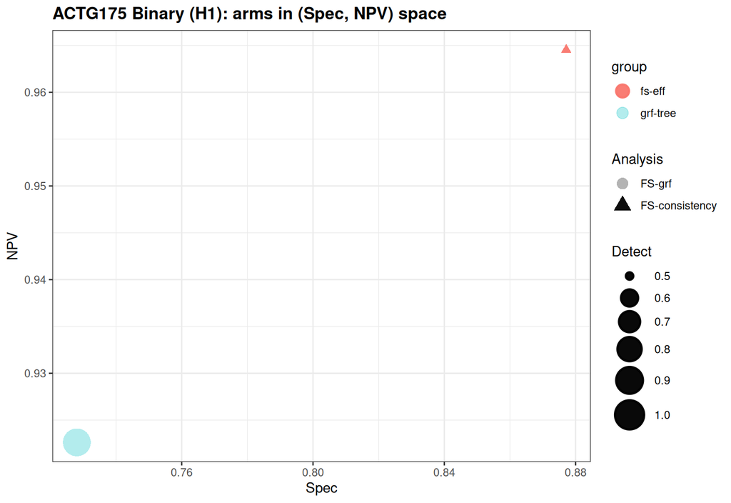

```r
oc_disp_alt <- oc_agg_from_results(results_alt)
oc_disp_alt <- compute_oc_pareto_flag(oc_disp_alt, metrics = c("Spec", "NPV"))
print(
  plot_oc_metrics(
    oc_disp_alt, x = "Spec", y = "NPV", z = "Detection",
    color_by = "group", shape_by = "Analysis",
    pareto_col = "pareto_frontier",
    title = "ACTG175 Binary (H1): arms in (Spec, NPV) space"
  )
)
```

## 6.6 Subgroup & Effect Distributions (flagship arm)

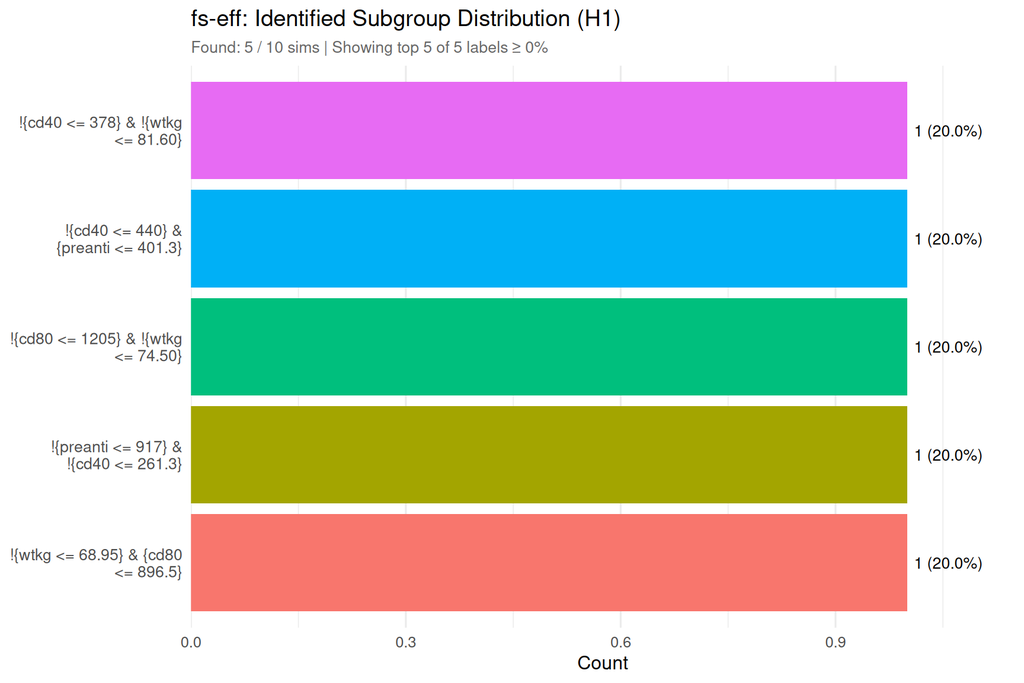

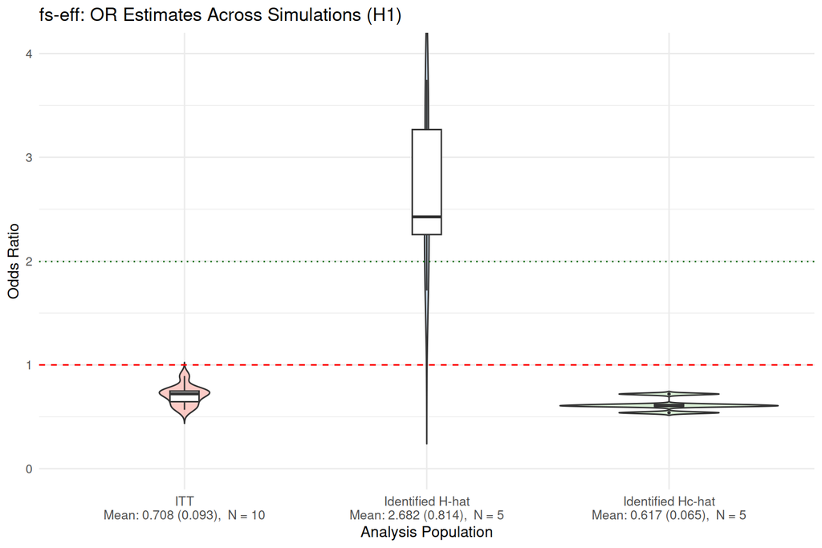

```r
flag_rows_alt <- results_alt[results_alt$analysis == FLAGSHIP_ARM, ]
if (nrow(flag_rows_alt) == 0L || sum(flag_rows_alt$any.H, na.rm = TRUE) == 0L) {
  cat(sprintf("*No detected subgroups for flagship arm `%s` under H1; ",
              FLAGSHIP_ARM),
      "subgroup/effect distributions skipped.*\n")
} else {
  flag_rows_alt[["sg.def"]] <- vapply(flag_rows_alt[["sg.def"]],
                                       tidy_sg_def, character(1), USE.NAMES = FALSE)
  print(plot_sg_distribution(
    flag_rows_alt,
    any_col = "any.H", label_col = "sg.def",
    min_pct = sgdist_min_pct_alt, top_k = sgdist_top_k,
    title = sprintf("%s: Identified Subgroup Distribution (H1)", FLAGSHIP_ARM)
  ))
  print(plot_effect_distribution(
    results           = results_alt,
    analysis_method   = FLAGSHIP_ARM,
    effect_measure    = "OR",
    subgroup_notation = sg_notation,
    reference_effect  = dgm_calibrated$hazard_ratios$harm_subgroup,
    ylim              = ordist_ylim,
    title             = sprintf("%s: OR Estimates Across Simulations (H1)",
                                FLAGSHIP_ARM)
  ))
}
```

# 7 Results: H0 (Null) — Type I Error

```r
format_oc_results(
  results_null,
  metrics           = c("detection", "classification"),
  digits            = 2,
  dgm               = dgm_null,
  subgroup_notation = sg_notation,
  title             = "ACTG175 Binary (H0): Type I Error, All Arms"
)
```

ACTG175 Binary (H0): Type I Error, All Arms

10 sims, OR(H) = NA, OR(Hᶜ) = 0.66

| Method | Sims | Found | Classification Sen | Classification Spec | Classification PPV | Classification NPV |
| --- | --- | --- | --- | --- | --- | --- |
| fs-eff | 10 | 0.40 | - | 0.92 | 0.00 | 1.00 |
| grf-tree | 10 | 1.00 | - | 0.78 | 0.00 | 1.00 |

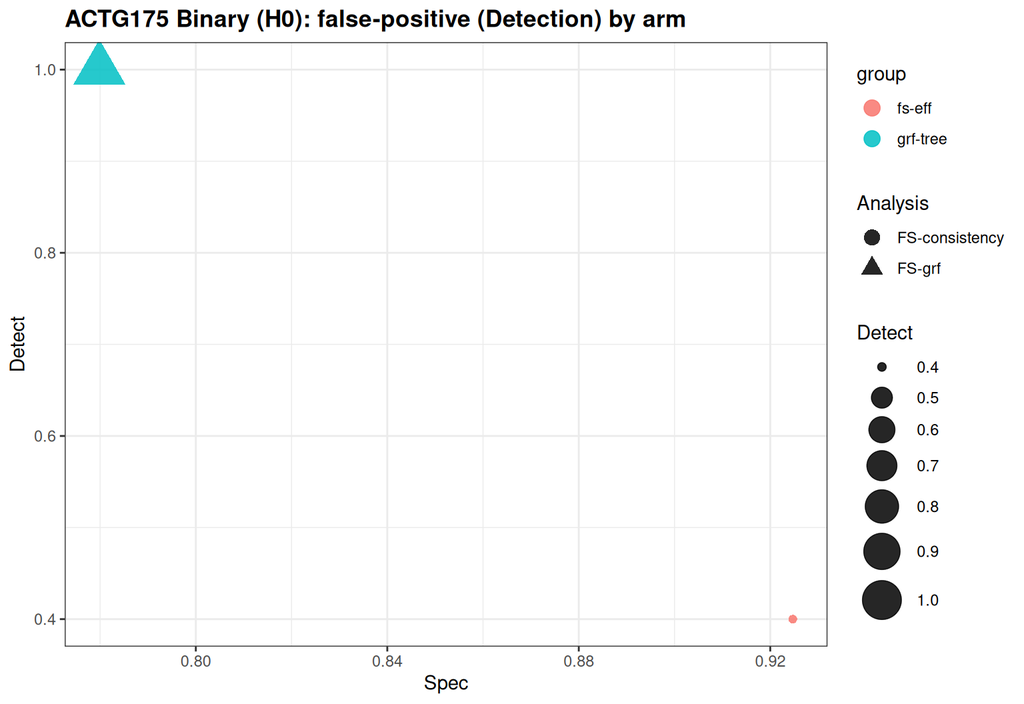

```r
oc_disp_null <- oc_agg_from_results(results_null)
print(
  plot_oc_metrics(
    oc_disp_null, x = "Spec", y = "Detection", z = "Detection",
    color_by = "group", shape_by = "Analysis",
    title = "ACTG175 Binary (H0): false-positive (Detection) by arm"
  )
)
```

# 8 Timing Summary

Computational Timing

| Stage | Seconds | Minutes |
| --- | --- | --- |
| Simulations H1 | 107.17 | 1.79 |
| Simulations H0 | 94.87 | 1.58 |